# ANLYTC3 R Homework 1

ZAREX ALVIN DARIA

The due date is 3:00pm 4 Feb 2022. Submit BOTH the Knit HTML file and the Rmd file.

```r
# create a vector with 4 numeric elements:
vec = c(4, 8, 13, 16)
# what is the sum of the elements?
a = sum(vec)
a
```

```
## [1] 41
```

```r
# these variables are badly named! This plot could be anything.
vec2 = c(3, 3, 8, 8)
vec
```

```
## [1]  4  8 13 16
```

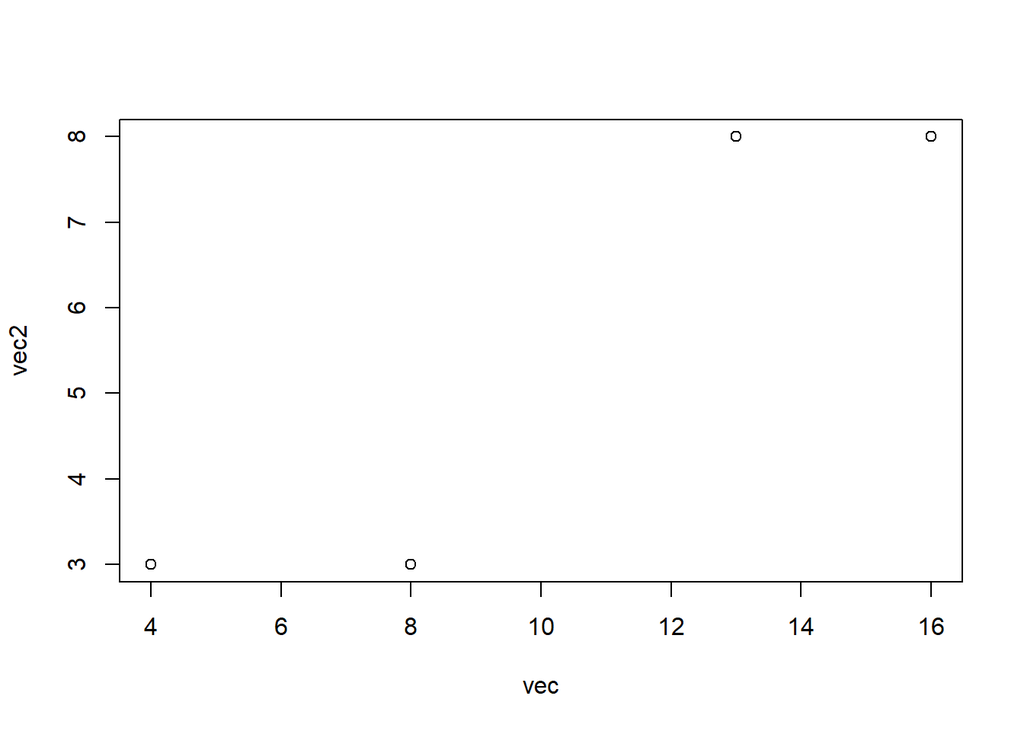

```r
plot( x = vec, y = vec2)
```

Here are some questions for you to complete:

1. Can you find the standard deviation of the vector `vec2`? (Hint: the command for standard deviation is in the self-study material for lecture 1, under “Commands that operate on vectors”)

```r
# Calculate the standard deviation
a <- sd(vec2)
a
```

```
## [1] 2.886751
```

2. Use the `c()` command to create a vector containing the text elements “MISM”, “MSPPM”, and “EPP”. Call this vector `department`.

```r
# Create vector out of text elements
department <- c("MISM", "MSPPM","EPP")
department
```

```
## [1] "MISM"  "MSPPM" "EPP"
```

Questions 3-4 use the `Orange` dataset, which comes built into R. Type `?Orange` to find out about the dataset, which contains the growth history of five different trees. (This brings up a help page. It won’t show up in this R markdown file) You can look at it by typing `View(Orange)` in your console window.

3. Use subset to extract the growth records corresponding to tree number 4. Call this data set `Orange.subset`

```r
# Extact growth records of Tree number 4 using subset
Orange.subset <- subset(Orange, Tree == 4)
Orange.subset
```

```
##    Tree  age circumference
## 22    4  118            32
## 23    4  484            62
## 24    4  664           112
## 25    4 1004           167
## 26    4 1231           179
## 27    4 1372           209
## 28    4 1582           214
```

4. Make a plot showing the `circumference` of tree number 4 as a function of its `age`.

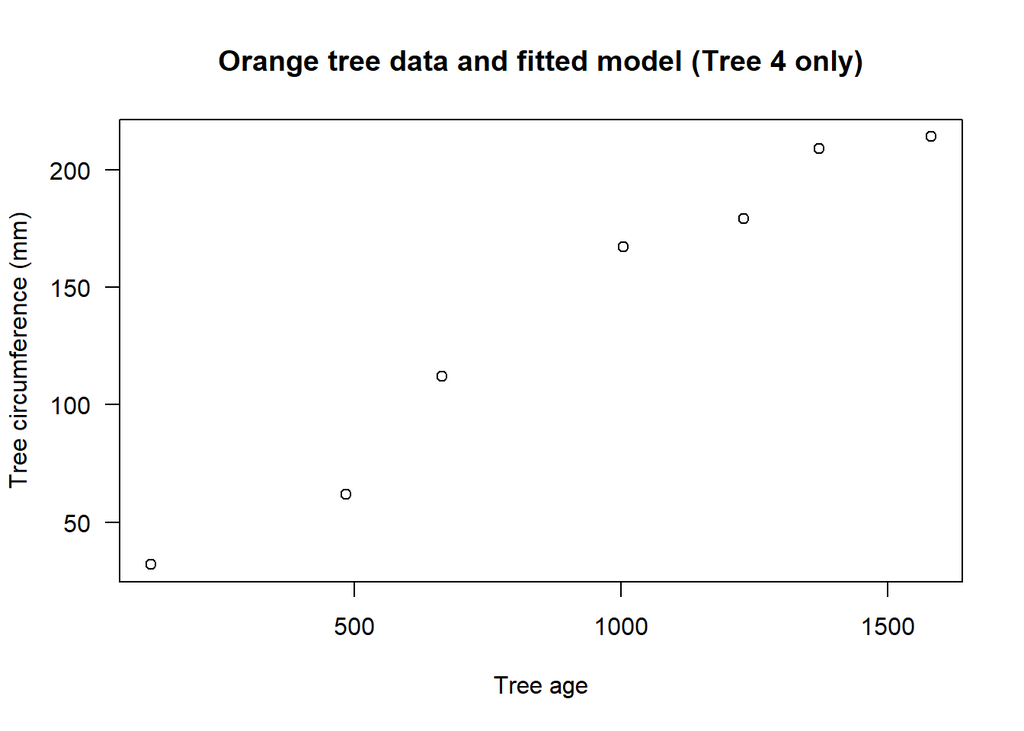

```r
# Create a plot with circumference and age as the axis
plot(circumference ~ age, data = Orange, subset = Tree == 4,
     xlab = "Tree age",
     ylab = "Tree circumference (mm)", las = 1,
     main = "Orange tree data and fitted model (Tree 4 only)")
```